# STA 6704 Project

Ken Zhao

4/19/2022

My dataset is an NBA basketball dataset from Kaggle.com. (https://www.kaggle.com/wyattowalsh/basketball). It has comprehensive stats from the first NBA season (1946-1947) to now, including games, players, and team stats. The initial problem I wanted to explore involved looking at individual players, but as I explored the data, I switched to looking at teams instead. I wanted to explore this particular dataset because I love the game of basketball and I am motivated to contribute to the game with data mining.

Here is the intial reading of the data. It is an sqlite file with multiple tables, so I read it in using RSQLite and checked the tables using DBI

```r
#read sqlite file
library(RSQLite)
library(DBI)

#create database
con=dbConnect(SQLite(),"/Users/divin/Downloads/archive/basketball.sqlite")

#check names of tables in database
tablenames=as.data.frame(dbListTables(con))
```

I then isolated the tables so I could explore the data individually.

I quickly realized here that there was not enough in-game player data for me to focus on specific players. General stats like how many points a player scored in a particular game were not well represented in any of the tables. Many of the tables here were extra statistics that are not useful on their own. For instance, player salary can be useful, but only if I have enough in-game player statistics to hold it to.

After parsing through the tables, I decided to switch my focus on analyzing team data instead of individual players.

The “Game” table was perfect for that. It had team stats on individual games. The other tables with team data in them were extraneous.

```r
#isolate tables
Draft=dbReadTable(con, 'Draft')
DraftCombine=dbReadTable(con, 'Draft_Combine')
Game=dbReadTable(con, 'Game')
GameInactivePlayers=dbReadTable(con, 'Game_Inactive_Players')
GameOfficials=dbReadTable(con, 'Game_Officials')
News=dbReadTable(con, 'News')
NewsMissing=dbReadTable(con, 'News_Missing')
Player=dbReadTable(con, 'Player')
PlayerAttributes=dbReadTable(con, 'Player_Attributes')
PlayerBios=dbReadTable(con, 'Player_Bios')
PlayerPhotos=dbReadTable(con, 'Player_Photos')
PlayerSalary=dbReadTable(con, 'Player_Salary')
Team=dbReadTable(con, 'Team')
TeamAttributes=dbReadTable(con, 'Team_Attributes')
TeamHistory=dbReadTable(con, 'Team_History')
TeamSalary=dbReadTable(con, 'Team_Salary')
```

This is just an example of data exploration I did

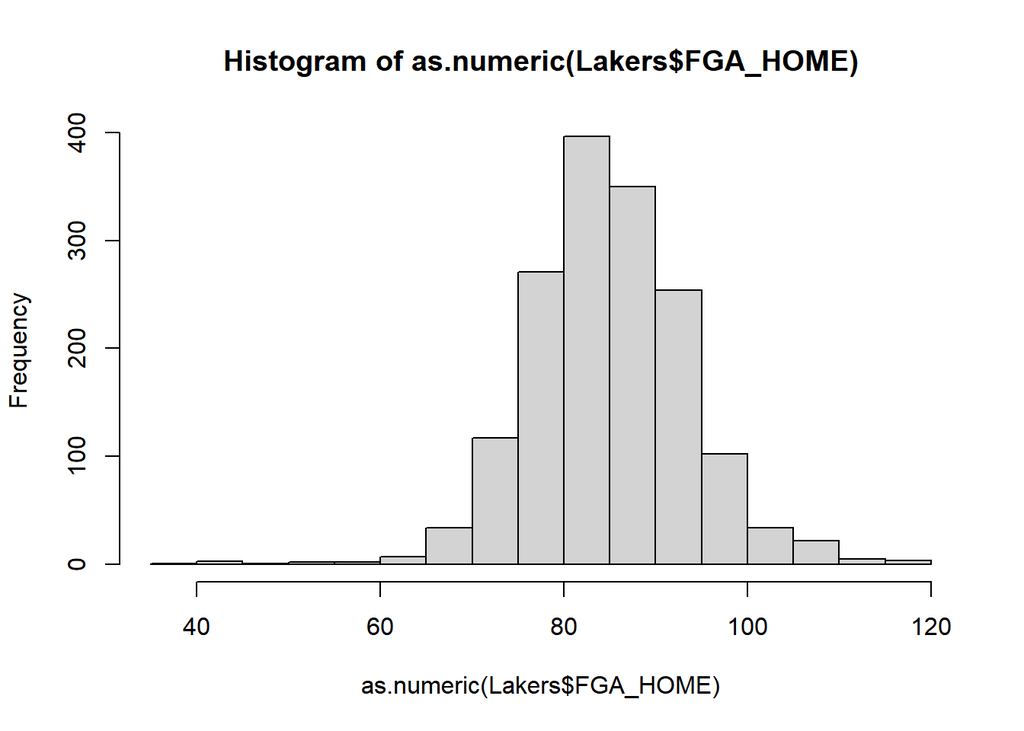

```r
#cursory exploration of data
Bulls=Game[which(Game$TEAM_NAME_HOME=="Chicago Bulls"),]
Lakers=Game[which(Game$TEAM_NAME_HOME=="Los Angeles Lakers"),]
#summary(Lakers)
hist(as.numeric(Lakers$FGA_HOME))
```

I removed the older games from the data set because they had many missing values

```r
#Separate games from before 1988 and 1988-now
Game1990<-Game[25000:65158,]

#Removed strange group of full NA observations
Game1990<-Game1990[1:37449,]
```

Here, I read through the variables I had, and used my domain knowledge to remove the redundant and useless ones. I wrote the original CSV to my laptop to easier remove the variables. Manually writing the code is an alternate way to create the pruned data, but I did the write/read method. I chose WL_HOME (Wins for home team) as my classification variable and 13 “AWAY” variables for my model. AWAY meaning stats accrued by the away team.

```r
#write Game1990 to laptop
write.csv(Game1990, "C:\\Users\\divin\\Desktop\\game1990.csv", row.names = F)

#prune data set manually on my laptop using domain knowledge#


#read pruned data set
teams=read.csv("C:\\Users\\divin\\Desktop\\game1990 - Copy.csv")


#remove incomplete observations
teams=na.omit(teams)
summary(teams)
```

```
##    WL_HOME             FGM_AWAY        FGA_AWAY        FG3M_AWAY
##  Length:37409       Min.   :16.00   Min.   : 55.00   Min.   : 0.000
##  Class :character   1st Qu.:34.00   1st Qu.: 77.00   1st Qu.: 3.000
##  Mode  :character   Median :37.00   Median : 82.00   Median : 6.000
##                     Mean   :37.33   Mean   : 82.82   Mean   : 6.286
##                     3rd Qu.:41.00   3rd Qu.: 88.00   3rd Qu.: 9.000
##                     Max.   :63.00   Max.   :129.00   Max.   :29.000
##    FG3A_AWAY        FTM_AWAY        FTA_AWAY        REB_AWAY
##  Min.   : 0.00   Min.   : 1.00   Min.   : 1.00   Min.   :20.00
##  1st Qu.:11.00   1st Qu.:14.00   1st Qu.:19.00   1st Qu.:37.00
##  Median :17.00   Median :18.00   Median :24.00   Median :42.00
##  Mean   :17.89   Mean   :18.29   Mean   :24.27   Mean   :41.77
##  3rd Qu.:23.00   3rd Qu.:22.00   3rd Qu.:29.00   3rd Qu.:46.00
##  Max.   :63.00   Max.   :52.00   Max.   :64.00   Max.   :81.00
##     AST_AWAY        STL_AWAY         BLK_AWAY         TOV_AWAY
##  Min.   : 4.00   Min.   : 0.000   Min.   : 0.000   Min.   : 3.00
##  1st Qu.:18.00   1st Qu.: 6.000   1st Qu.: 3.000   1st Qu.:12.00
##  Median :21.00   Median : 8.000   Median : 4.000   Median :15.00
##  Mean   :21.66   Mean   : 7.801   Mean   : 4.672   Mean   :14.95
##  3rd Qu.:25.00   3rd Qu.:10.000   3rd Qu.: 6.000   3rd Qu.:18.00
##  Max.   :52.00   Max.   :24.000   Max.   :19.000   Max.   :37.00
##     PF_AWAY         PTS_AWAY
##  Min.   : 5.00   Min.   : 53.00
##  1st Qu.:19.00   1st Qu.: 90.00
##  Median :22.00   Median : 99.00
##  Mean   :21.92   Mean   : 99.23
##  3rd Qu.:25.00   3rd Qu.:108.00
##  Max.   :52.00   Max.   :168.00
```

```r
#transform win/loss variable to categorical
teams=transform(teams, WL_HOME=as.factor(WL_HOME))
```

I remove SEASON here because I don’t need it for the model, and I put the split at 2014 and 2015 based on my knowledge on when the game shifted to shooting more 3 pointers

```r
#split data from before 2014 to after 2014, and also remove SEASON
teams$SEASON=NULL

team2014=teams[1:30380,]

team2015=teams[30380:37348,]
```

I sampled my training and test data from the split I did above

```r
#create test and training data from split data above
set.seed(1)

sample2014=team2014[sample(1:nrow(team2014),500),]

test2015=team2015[sample(1:nrow(team2015),100),]
```

I wanted to run random forest for my model and check the variables with boosting

```r
#Random forest
library(randomForest)
```

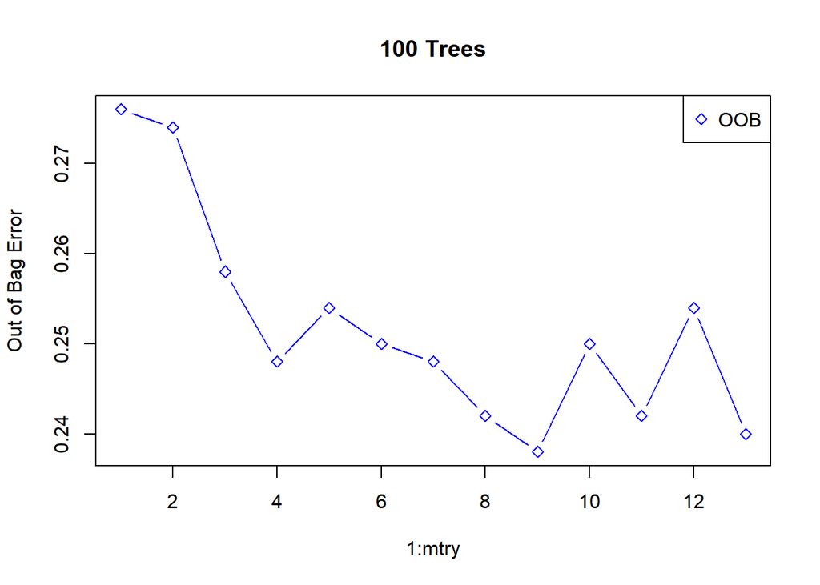

```r
#out of bag error for 1 to 13 variables mtry
oob.err = double(13)
for(mtry in 1:13){
  fit = randomForest(WL_HOME~., data = sample2014, mtry=mtry, ntree = 100)
  oob.err[mtry] = fit$err.rate[100]
}
#plot out of bag error
matplot(1:mtry,  oob.err, pch = 23, col = c("blue"), type = "b", ylab="Out of Bag Error")
legend("topright", legend = c("OOB"), pch = 23, col = c( "blue"))
title(main="100 Trees")
```

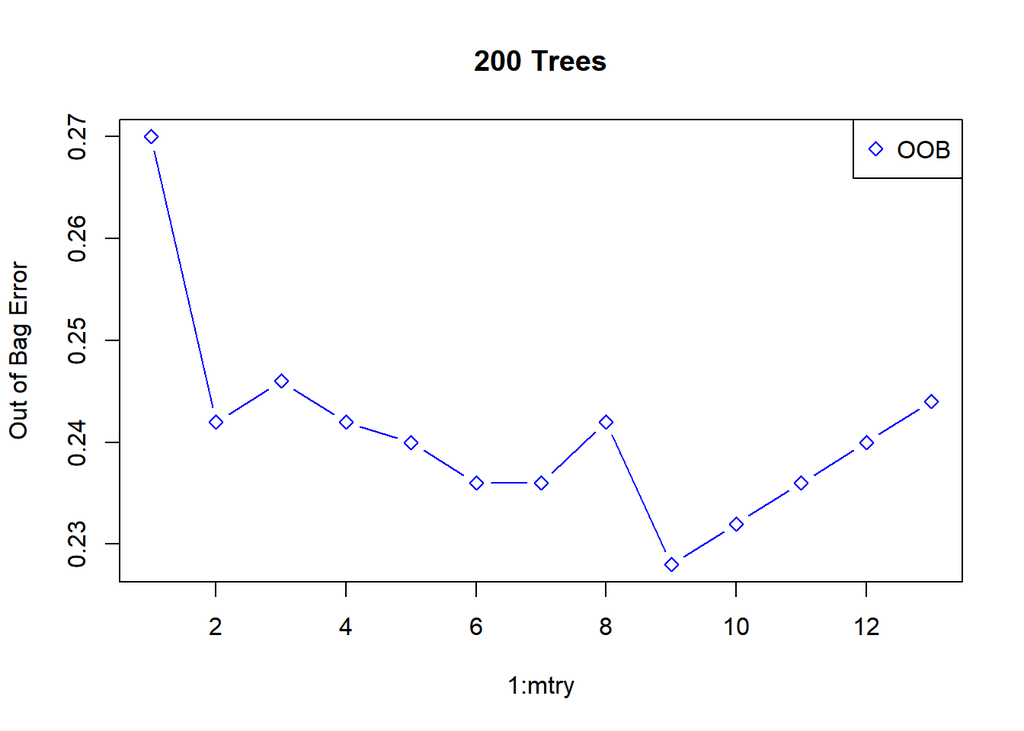

```r
oob.err = double(13)
for(mtry in 1:13){
  fit = randomForest(WL_HOME~., data = sample2014, mtry=mtry, ntree = 200)
  oob.err[mtry] = fit$err.rate[200]
}

matplot(1:mtry,  oob.err, pch = 23, col = c("blue"), type = "b", ylab="Out of Bag Error")
legend("topright", legend = c("OOB"), pch = 23, col = c( "blue"))
title(main="200 Trees")
```

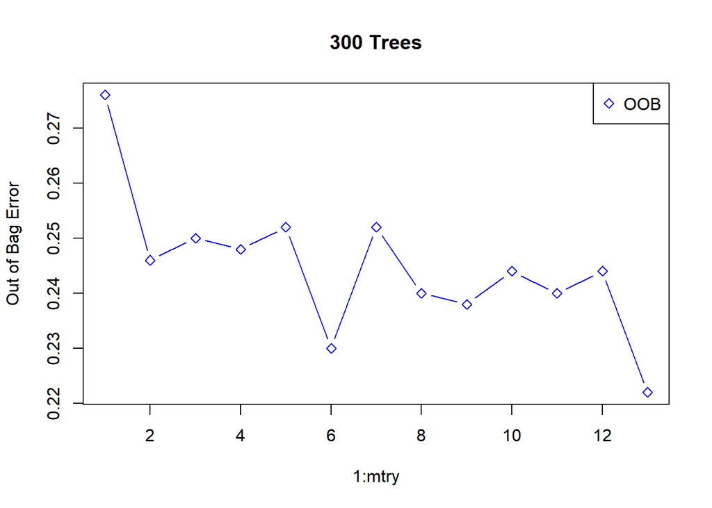

```r
oob.err = double(13)
for(mtry in 1:13){
  fit = randomForest(WL_HOME~., data = sample2014, mtry=mtry, ntree = 300)
  oob.err[mtry] = fit$err.rate[300]
}

matplot(1:mtry,  oob.err, pch = 23, col = c("blue"), type = "b", ylab="Out of Bag Error")
legend("topright", legend = c("OOB"), pch = 23, col = c( "blue"))
title(main="300 Trees")
```

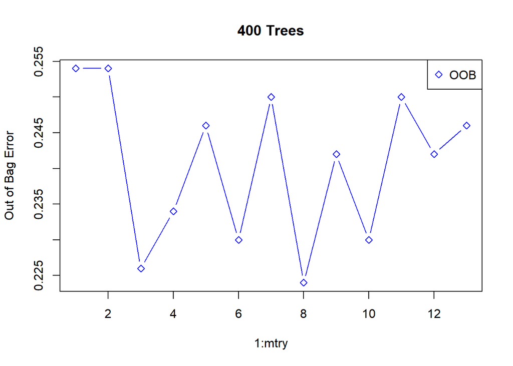

```r
oob.err = double(13)
for(mtry in 1:13){
  fit = randomForest(WL_HOME~., data = sample2014, mtry=mtry, ntree = 400)
  oob.err[mtry] = fit$err.rate[400]
}

matplot(1:mtry,  oob.err, pch = 23, col = c("blue"), type = "b", ylab="Out of Bag Error")
legend("topright", legend = c("OOB"), pch = 23, col = c( "blue"))
title(main="400 Trees")
```

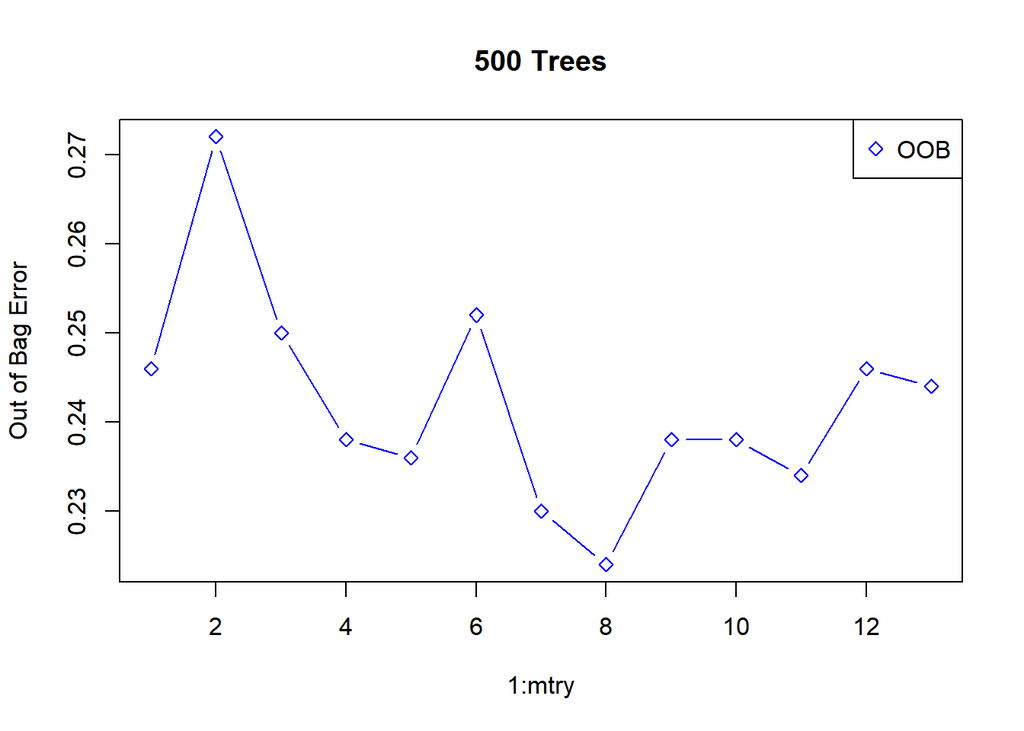

```r
oob.err = double(13)
for(mtry in 1:13){
  fit = randomForest(WL_HOME~., data = sample2014, mtry=mtry, ntree = 500)
  oob.err[mtry] = fit$err.rate[500]
}

matplot(1:mtry,  oob.err, pch = 23, col = c("blue"), type = "b", ylab="Out of Bag Error")
legend("topright", legend = c("OOB"), pch = 23, col = c( "blue"))
title(main="500 Trees")
```

I ran the random forest model using values from the graphs above. Here is one of the examples below. Then I used caret to calculate the accuracy. Most of the time, I got around 60% on the low end and 70% on the high end.

```r
#run random forest model based on OOB graphs
rftrain=randomForest(WL_HOME~.,data = sample2014,mtry=3,ntree=200)
rftrain
```

```
##
## Call:
##  randomForest(formula = WL_HOME ~ ., data = sample2014, mtry = 3,      ntree = 200)
##                Type of random forest: classification
##                      Number of trees: 200
## No. of variables tried at each split: 3
##
##         OOB estimate of  error rate: 25.6%
## Confusion matrix:
##     L   W class.error
## L 129  78   0.3768116
## W  50 243   0.1706485
```

```r
#prediction confusion matrix
library(caret)
pred = predict(rftrain, newdata=test2015[-1])
cm=confusionMatrix(pred,test2015[,1])
cm
```

```
## Confusion Matrix and Statistics
##
##           Reference
## Prediction  L  W
##          L 38 23
##          W  5 34
##
##                Accuracy : 0.72
##                  95% CI : (0.6213, 0.8052)
##     No Information Rate : 0.57
##     P-Value [Acc > NIR] : 0.001409
##
##                   Kappa : 0.4567
##
##  Mcnemar's Test P-Value : 0.001315
##
##             Sensitivity : 0.8837
##             Specificity : 0.5965
##          Pos Pred Value : 0.6230
##          Neg Pred Value : 0.8718
##              Prevalence : 0.4300
##          Detection Rate : 0.3800
##    Detection Prevalence : 0.6100
##       Balanced Accuracy : 0.7401
##
##        'Positive' Class : L
##
```

Load the boost package and rewrite the Win/loss variable to 1/0

```r
#gradient boosting
library(gbm)
#rewrite win/loss as 0/1
sample2014$WL_HOME=ifelse(sample2014$WL_HOME=="W",1,0)
test2015$WL_HOME=ifelse(test2015$WL_HOME=="W",1,0)
```

Here, I run the boost and look at the variable importance. I expect to see Away Points (PTS_AWAY) being high and Away 3 pointers (FG3M_AWAY) being low. Running it a few times does yield what I expect. This is because the team who scores more points wins the game. For the 3 pointers, I expected it to have low importance because the years for the test data (2015-now) has much more 3 pointers in the game style.

```r
#run boost
boost=gbm(WL_HOME ~ . ,data = sample2014,n.trees = 10000,
                 shrinkage = 0.01, interaction.depth = 4)
```

```
## Distribution not specified, assuming bernoulli ...
```

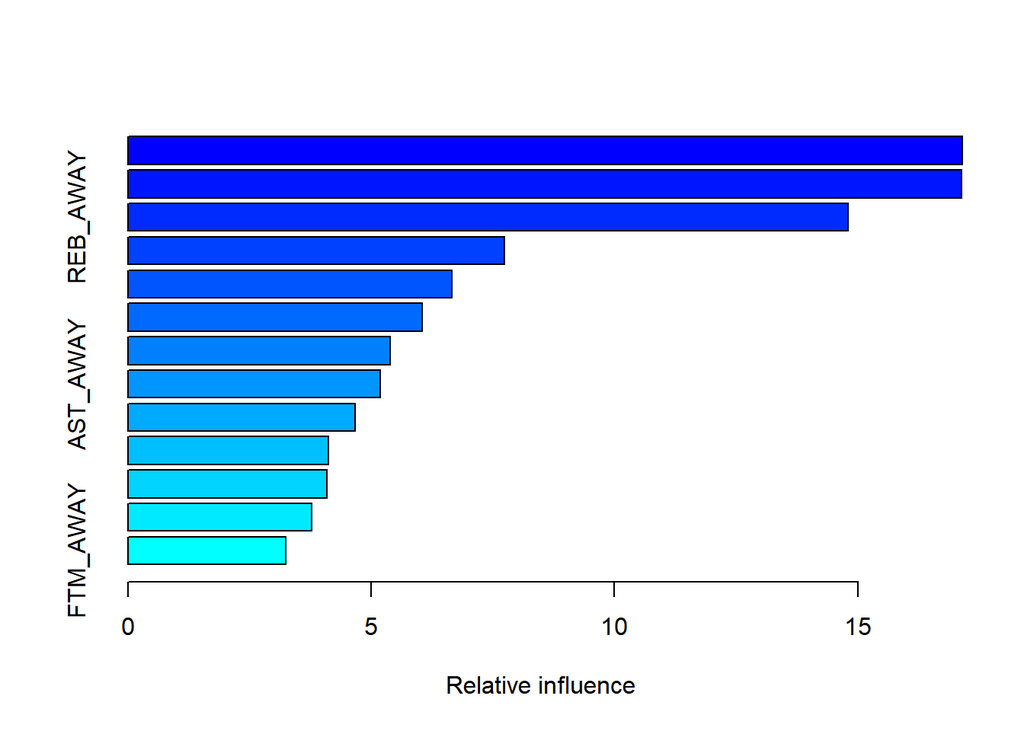

```
##                 var   rel.inf
## FGA_AWAY   FGA_AWAY 17.149014
## PTS_AWAY   PTS_AWAY 17.139018
## REB_AWAY   REB_AWAY 14.804790
## PF_AWAY     PF_AWAY  7.745825
## TOV_AWAY   TOV_AWAY  6.658469
## STL_AWAY   STL_AWAY  6.042388
## FG3A_AWAY FG3A_AWAY  5.384524
## AST_AWAY   AST_AWAY  5.188619
## FG3M_AWAY FG3M_AWAY  4.663799
## FTA_AWAY   FTA_AWAY  4.118427
## BLK_AWAY   BLK_AWAY  4.095833
## FGM_AWAY   FGM_AWAY  3.770663
## FTM_AWAY   FTM_AWAY  3.238631
```

```r
#variable importance
summary(boost)
```

Finally, here are some partial dependency plots

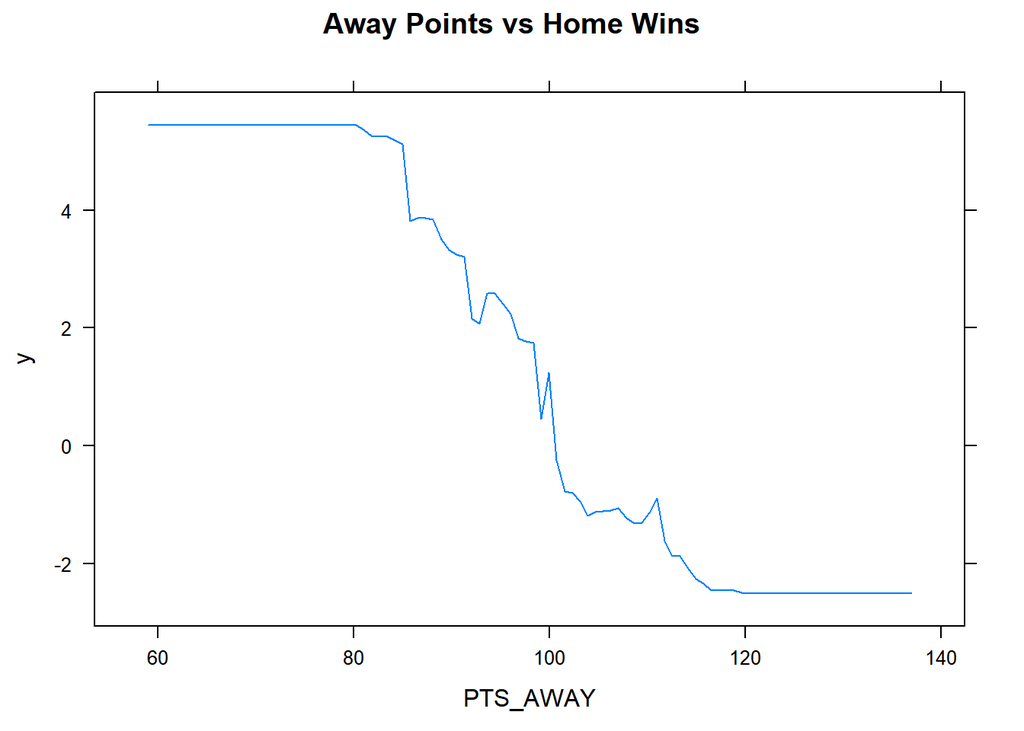

```r
#partial dependency plots
plot(boost,i= "PTS_AWAY", main= "Away Points vs Home Wins")
```

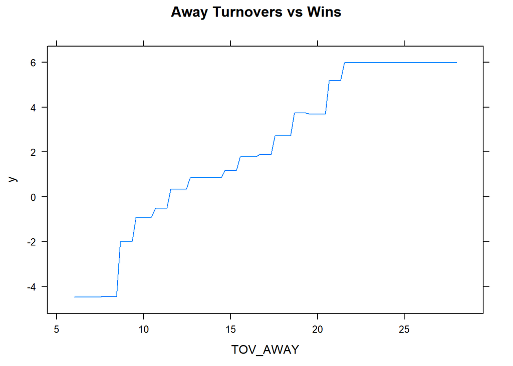

```r
plot(boost,i= "TOV_AWAY", main= "Away Turnovers vs Wins")
```

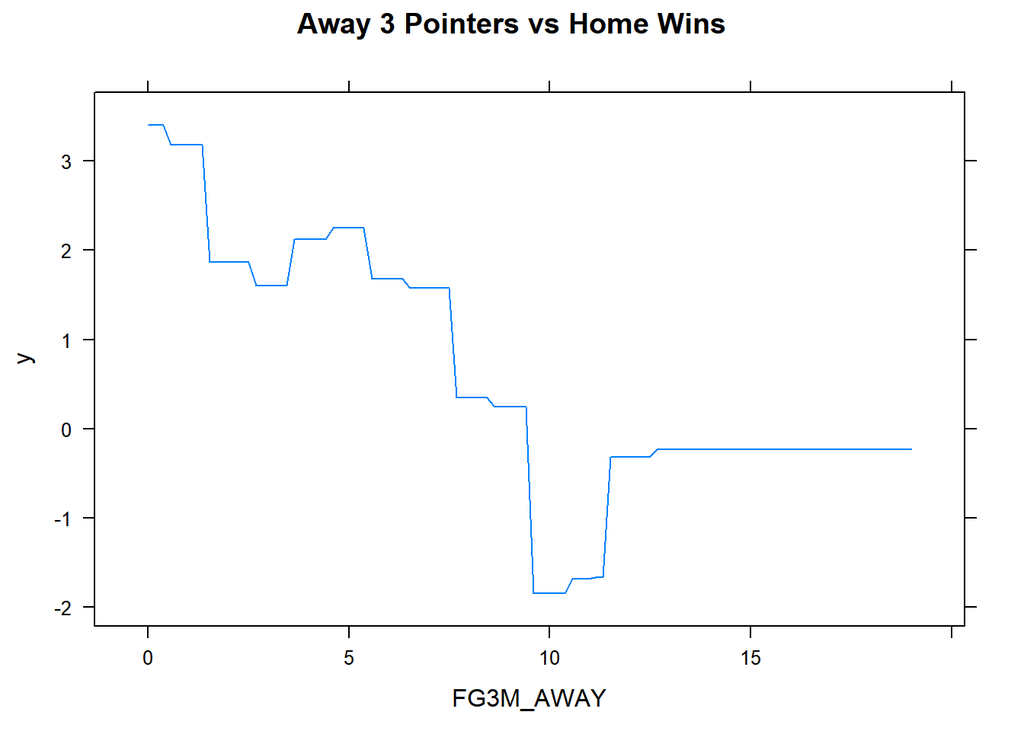

```r
plot(boost,i= "FG3M_AWAY", main= "Away 3 Pointers vs Home Wins")
```

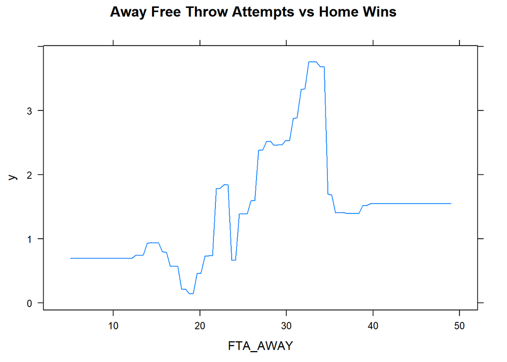

```r
plot(boost,i= "FTA_AWAY", main= "Away Free Throw Attempts vs Home Wins")
```

For my model, I ran random forest several times with 2-4 mtry and many different trees. I always got around 20-25% OOB error and around 70ish accuracy.

Looking at the variable importance, I believe 3 pointers were the biggest difference in accounting for the error. Running the boosting on variable importance always showed FG3M_AWAY, the number of three pointers away teams made, at or towards the bottom.

Perhaps in the future, I would run this with different models and also with a different mix of variables. There were many in the “game” table that I did not use. To me, based on domain knowledge, the ones I used were some of the most important, especially 3 pointers, given how few 3 pointers were taken in the training data vs how many were taken in the test set.